# Text Mining: Bag of Words

## Visualizing Multiple Documents

### Common Words

`commonality.cloud()` allows you to find common words across multiple documents.

For each document, collapse the text into a single vector.

Next, combine each new text vector into a single dataframe.

Finally convert the dataframe to a vector source, and then to a corpus.

```r
# use qdap sample datasets hamlet and raj (romeo and juliet)
hamlet <- hamlet
raj <- raj
#create all_hamlet
all_hamlet <- paste(hamlet$dialogue, collapse = " ")
#create all_raj
all_raj <- paste(raj$dialogue, collapse = " ")
#create all_dialogue
all_dialogue <- c(all_hamlet, all_raj)
#convert to vector source
all_dialogue <- VectorSource(all_dialogue)
#Create all_corpus
all_corpus <- VCorpus(all_dialogue)
inspect(all_corpus)
```

```
<<VCorpus>>
Metadata:  corpus specific: 0, document level (indexed): 0
Content:  documents: 2

[[1]]
<<PlainTextDocument>>
Metadata:  7
Content:  chars: 155362

[[2]]
<<PlainTextDocument>>
Metadata:  7
Content:  chars: 125524
```

Next, we will create a function to clean up the corpus using the `qdap` & `tm`functions we learned about earlier.

Then we will make a term document matrix, convert it to a matrix and finally,

we will then use the `commonality.cloud()` function to view the words that are similar between the two documents. The function takes on the argument of a matrix where it the rows are the words and the columns are the documents. RowSums need not be applied here.

```r
# Clean the corpus
all_clean <- clean_corpus(all_corpus)
inspect(all_clean)
```

```
<<VCorpus>>
Metadata:  corpus specific: 0, document level (indexed): 0
Content:  documents: 2

[[1]]
<<PlainTextDocument>>
Metadata:  7
Content:  chars: 106838

[[2]]
<<PlainTextDocument>>
Metadata:  7
Content:  chars: 89021
```

```r
# Create all_tdm
all_tdm <- TermDocumentMatrix(all_clean)
# Create all_m
all_m <- as.matrix(all_tdm)
head(all_m, 10)
```

```
            Docs
Terms        1 2
  abate      1 1
  abatements 1 0
  abbey      0 1
  abed       0 1
  abhorred   1 1
  abhors     0 1
  ability    1 0
  able       1 2
  ableeding  0 1
  aboard     3 1
```

```r
tail(all_m, 10)
```

```
          Docs
Terms       1  2
  yoricks   1  0
  youll     3  4
  young    17 23
  younger   1  2
  youngest  0  1
  youth    16  6
  youthful  0  3
  youwhy    1  0
  zone      1  0
  zounds    0  2
```

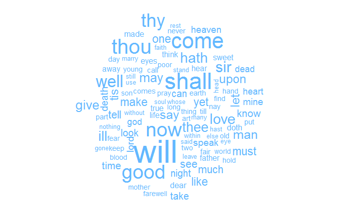

```r
# Print a commonality cloud
commonality.cloud(all_m, max.words = 100, colors = "steelblue1")
```

### Dissimilar Words

Visualizing dissimilar words is very similar to what we did above except, to keep track of which words come from which document, we add column names to the term document matrix.

```r
set.seed(119)

# Give the columns distinct names
colnames(all_tdm) <- c("Hamlet", "Romeo & Juliet")

# Create all_m
all_m <- as.matrix(all_tdm)

# Create comparison cloud
comparison.cloud(all_m, max.words = 50, colors = sample(colors(), 2))
```

[output not shown]

## Polarized Tag Cloud

A commonality.cloud() may be misleading since words could be represented disproportionately in one corpus or the other, even if they are shared. In the commonality cloud, they would show up without telling you which one of the corpora has more term occurrences. To solve this problem, we can create a pyramid.plot() from the plotrix package.

We can use the existing matrix consisting of the frequency of words from each document. We will then subset the document to extract out the words that appear in both documents. From there we can find the absolute difference between words from each document and plot various ways using the `pyramid.plot` function. Let’s try it out.

```r
#create common_words
common_words <- subset(all_m, all_m[ ,1] > 0 & all_m[, 2] > 0)
#create difference
difference <- abs(common_words[,1] - common_words[, 2])
#combine common_words & difference
common_words <- cbind(common_words, difference)
head(common_words)
```

```
         Hamlet Romeo & Juliet difference
abate         1              1          0
abhorred      1              1          0
able          1              2          1
aboard        3              1          2
abroad        1              3          2
abuse         1              1          0
```

```r
#Order the df from most differences to least
common_words <- common_words[order(common_words[, 3], decreasing = TRUE), ]
head(common_words)
```

```
     Hamlet Romeo & Juliet difference
lord    211             30        181
thou     99            276        177
thee     57            139         82
thy      86            167         81
love     63            134         71
king     65              2         63
```

```r
#create a top_25df to make it easier to plot the top_25 words with the greatest differences
top_25df <- data.frame(Hamlet = common_words[1:25, 1],
                       `R & J` = common_words[1:25, 2],
                       labels = rownames(common_words[1:25, ]))
top_25df
```

|  | Hamlet | R...J | labels |
| --- | --- | --- | --- |
| lord | 211 | 30 | lord |
| thou | 99 | 276 | thou |
| thee | 57 | 139 | thee |
| thy | 86 | 167 | thy |
| love | 63 | 134 | love |
| king | 65 | 2 | king |
| let | 94 | 45 | let |
| like | 80 | 40 | like |
| art | 17 | 54 | art |
| know | 72 | 35 | know |

[output cut: 15 more lines]

```
[1] 5.1 4.1 2.1 2.1
```

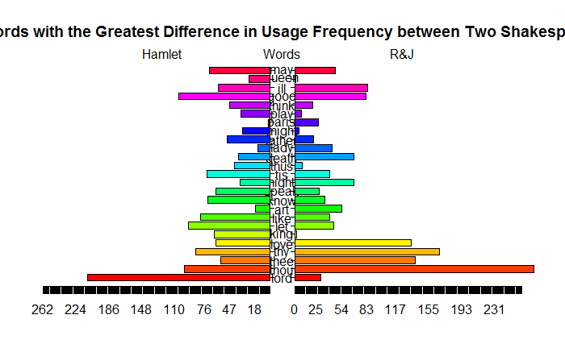

```r
#load plotrix package for pyramid plot
library(plotrix)
pyramid.plot(lx = top_25df$Hamlet,
             rx = top_25df$R...J,
             labels = top_25df$labels,
             gap = 14, space = 0.2,
             top.labels = c("Hamlet", "Words", "R&J"), main = "Common Words with the Greatest Difference in Usage Frequency between Two Shakesperean Plays",
             laxlab = NULL,
             raxlab = NULL,
             unit = NULL)
```

## Word Network

Another way to view word connections is to treat them as a network, similar to a social network. Word networks show term association and cohesion. A word of caution: these visuals can become very dense and hard to interpret visually.

In a network graph, the circles are called nodes and represent individual terms, while the lines connecting the circles are called edges and represent the connections between the terms.

`qdap` provides a shorcut for making word networks. The `word_network_plot()` and `word_associate()` functions both make word networks easy!

```r
# Word association
word_associate(hamlet$dialogue,
               match.string = "queen",
               stopwords = stopwords(kind = "en"),
               network.plot = TRUE, cloud.colors = c("red", "steelblue3"))
```

```
    row group unit                                                                                                                          text                                                                                                                                                            …
1    89   all   89 Therefore our sometime sister, now our queen, The imperial jointress to this warlike state, Have we, as 'twere with a defeated joy,-- With an auspicious and a dropping eye, With mirth in funeral and with dirge in marriage, In equal scale weighing delight and dole,-- Taken to wife:…
2   354   all  354 --won to his shameful lust The will of my most seeming-virtuous queen: O Hamlet, what a falling-off was there!
3   360   all  360 Thus was I, sleeping, by a brother's hand Of life, of crown, of queen, at once dispatch'd: Cut off even in the blossoms of my sin, Unhousel'd, disappointed, unanel'd, No reckoning made, but sent to my account With all my imperfections on my head: O, horrible!
4   552   all  552 But what might you think, When I had seen this hot love on the wing-- As I perceived it, I must tell you that, Before my daughter told me--what might you, Or my dear majesty your queen here, think, If I had play'd the desk or table-book, Or given my heart a winking, mute and dumb,…
5   646   all  646 You were sent for; and there is a kind of confession in your looks which your modesties have not craft enough to colour: I know the good king and queen have sent for you.
6   654   all  654 I will tell you why; so shall my anticipation prevent your discovery, and your secrecy to the king and queen moult no feather.
7   747   all  747 'The mobled queen?
8   748   all  748 That's good; 'mobled queen' is good.
9   880   all  880 My lord, do as you please; But, if you hold it fit, after the play Let his queen mother all alone entreat him To show his grief: let her be round with him; And I'll be placed, so please you, in the ear Of all their conference.
10  896   all  896 And the queen too, and that presently.
11 1049   all 1049 The queen, your mother, in most great affliction of spirit, hath sent me to you.
12 1089   all 1089 My lord, the queen would speak with you, and presently.
13 1126   all 1126 That cannot be; since I am still possess'd Of those effects for which I did the murder, My crown, mine own ambition and my queen.
14 1164   all 1164 No, by the rood, not so: You are the queen, your husband's brother's wife; And--would it were not so!
15 1254   all 1254 'Twere good you let him know; For who, that's but a queen, fair, sober, wise, Would from a paddock, from a bat, a gib, Such dear concernings hide?
16 1530   all 1530 The queen his mother Lives almost by his looks; and for myself-- My virtue or my plague, be it either which-- She's so conjunctive to my life and soul, That, as the star moves not but in his sphere, I could not but by her.
17 1536   all 1536 Letters, my lord, from Hamlet: This to your majesty; this to the queen.
18 1591   all 1591 How now, sweet queen!
19 1737   all 1737 The queen, the courtiers: who is this they follow?
20 1877   all 1877 The king and queen and all are coming down.
21 1879   all 1879 The queen desires you to use some gentle entertainment to Laertes before you fall to play.
22 1935   all 1935 Here, Hamlet, take my napkin, rub thy brows; The queen carouses to thy fortune, Hamlet.
23 1952   all 1952 Look to the queen there, ho!
24 1957   all 1957 How does the queen?
25 1980   all 1980 Wretched queen, adieu!
```

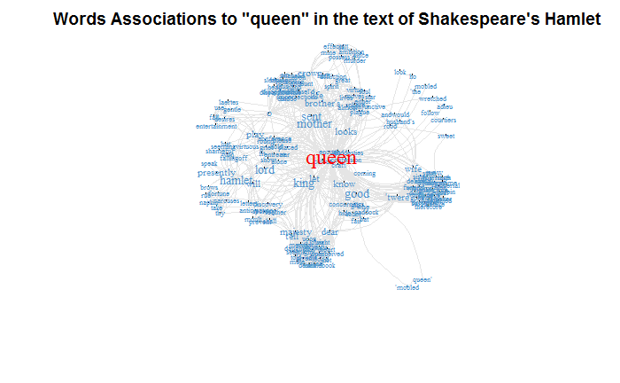

```r
# Add title
title(main = "Words Associations to \"queen\" in the text of Shakespeare's Hamlet")
```

# Word Clustering

A simple way to do word cluster analysis is with a dendrogram on your term-document matrix. Once you have a TDM, you can call dist() to compute the differences between each row of the matrix.

Next, you call hclust() to perform cluster analysis on the dissimilarities of the distance matrix. Lastly, you can visualize the word frequency distances using a dendrogram and plot(). Often in text mining, you can tease out some interesting insights or word clusters based on a dendrogram.

A note on sparsity:

```r
#view the dimension of the presidents term document matrix
dim(pres_tdm)
```

```
[1] 1225   94
```

```r
#evaluate the function  remove sparse terms at 0.95 and 0.975 sparsity
tdm1 <- removeSparseTerms(pres_tdm, sparse = 0.95)
tdm1
```

```
<<TermDocumentMatrix (terms: 164, documents: 94)>>
Non-/sparse entries: 1428/13988
Sparsity           : 91%
Maximal term length: 14
Weighting          : term frequency (tf)
```

```r
tdm2 <- removeSparseTerms(pres_tdm, sparse = 0.975)
tdm2
```

```
<<TermDocumentMatrix (terms: 300, documents: 94)>>
Non-/sparse entries: 1881/26319
Sparsity           : 93%
Maximal term length: 14
Weighting          : term frequency (tf)
```

Now that we’ve applied sparsity to the term document matrix, we can put everythin we’ve learned together to create a dendrogram of the clustered words.

First we need to convert the tdm to a matrix, then to a data frame in order to apply the distribution function `dist()` to it. Finally we can create an `hclust()` object and plot it.

```r
#remove sparse terms from tdm as above
pres_tdm2 <- removeSparseTerms(pres_tdm, sparse = 0.90)
pres_tdm2
```

```
<<TermDocumentMatrix (terms: 49, documents: 94)>>
Non-/sparse entries: 697/3909
Sparsity           : 85%
Maximal term length: 10
Weighting          : term frequency (tf)
```

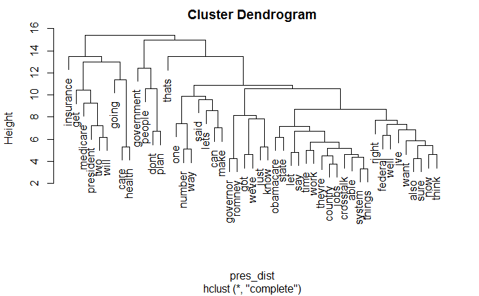

```r
#create matrix
tdm_m <- as.matrix(pres_tdm2)
#create data frame
tdm_df <- data.frame(tdm_m)
#create distance (dist) of terms of tdm_df
pres_dist <- dist(tdm_df)
#create a cluster analysis object
hc <- hclust(pres_dist)
plot(hc)
```

### Dendrogram Aesthetics

Use the `dendextend` package to improve the aesthetics of your dendrogram.

```r
library(dendextend)

#using the hclust object from above, create an as.dendrogram object
hcd <- as.dendrogram(hc)

labels(hcd)

#change branch colors
hcd <- branches_attr_by_labels(dend = hcd, labels = c("health", "care"))

plot(hcd)
# or this way
clusters <-cutree(hcd, 3)
hcd <- branches_attr_by_clusters(hcd, clusters, c("green", "blue", "orange"))

plot(hcd)

#add cluster rectangles
rect.dendrogram(hcd, k = 3, border = "steelblue")
```

[output not shown]

## Word Association

Another way to think about word relationships is with the `findAssocs()` function in the `tm` package. For any given word, `findAssocs()` calculates its correlation with every other word in a TDM or DTM. Scores range from 0 to 1. A score of 1 means that two words always appear together, while a score of 0 means that they never appear together.

To use `findAssocs()` pass in a TDM or DTM, the search term, and a minimum correlation. The function will return a list of all other terms that meet or exceed the minimum threshold.

```r
library(ggplot2)
library(ggthemes)
# Create associations
associations <- findAssocs(pres_tdm, "government", 0.5)

# View the venti associations
associations

# Create associations_df
associations_df <- list_vect2df(associations)[,2:3]

# Plot the associations_df values
ggplot(associations_df, aes(y = associations_df[, 1])) +
  geom_point(aes(x = associations_df[, 2]),
             data = associations_df, size = 3) +
  theme_gdocs() +
  labs(title = "Words associated with 'government' with a 50% frequency")
```

[output not shown]

## Tokenizing Words

So far we have only created document matrices using single or unigram words. But we can also combine words, also known as tokenizing, to gain more insight into our text mining analysis.

Take not good for example. not good as a phrase or token has a significantly different meaning than each of the words apart.

The `rweka` package is useful for tokenizing words as we will practice below.

```r
#load the rweka package
library(RWeka)

# Make tokenizer function
tokenizer <- function(x){
  NGramTokenizer(x, Weka_control(min = 2, max = 2))}

#create a vector source from the `dialogue` variable of the raj data frame
pres_source <- VectorSource(presidents$dialogue)

#convert the vector source into a corpus
pres_corp <- VCorpus(pres_source)

#clean the corpus using the clean_corp function we created earlier
pres_corp <- clean_corpus(pres_corp)


# Create unigram_dtm using the raj_corpus we created above
unigram_dtm <- DocumentTermMatrix(pres_corp)

# Create bigram_dtm
bigram_dtm <- DocumentTermMatrix(pres_corp, control = list(tokenize = tokenizer))

# Examine unigram_dtm
unigram_dtm

# Examine bigram_dtm
bigram_dtm
```

[output not shown]

Let’s see how this affects a wordcloud/visualizations.

```r
#convert bigram_dtm into a matrix
bigram_matrix <- as.matrix(bigram_dtm)

dim(bigram_matrix)

#take a look at a portion of the matrix
bigram_matrix[40:55, 1500:1515]

#create a frequency table
freq <- colSums(bigram_matrix)

#sort by the most frequent words first
freq <- sort(freq, decreasing = TRUE)

bi_words <- names(freq)
head(bi_words)
#plot a wordcloud

wordcloud(words = bi_words, freq, max.words = 25, rot.per = .45)
```

[output not shown]

# Mapping MetaData to your Corpus

It is possible to add the metadata of the document you are trying to convert to a document matrix.

```r
custom_reader <- readTabular(mapping = list(content = "dialogue",
                                            id = "person"))
custom_corpus <- VCorpus(DataframeSource(presidents),
                         readerControl = list(reader = custom_reader))
#view the metadata dialogue
custom_corpus[[1]][1]
```

```
$content
[1] "We'll talk about -- specifically about health care in a moment. But what -- do you support the voucher system, Governor?"
```

```r
#view the metadata id
custom_corpus[[1]][2]
```

```
$meta
  id      : LEHRER
  language: en
```